# COVID-19 Report

Ketki joshi

2024-04-13

Selected variables in the dataset:

- AGE : age of the patient (continuous)
- SEX : sex of the patient (1= female, 2= male)
- PREGNANT : whether the patient is pregnant or not (1= yes, 2= no, 97 and 99= NA)
- ICU : Indicates whether the patient had been admitted to an Intensive Care Unit (1= yes, 2= no, 97 and 99= NA)
- PATIENT_TYPE : type of care the patient received in the unit. (1= returned home, 2= hospitalization.
- PNEUMONIA : whether the patient already have air sacs inflammation or noT (1= yes, 2= no, 99= NA)

Characteristics of the COVID-19 patients are displayed in the table below. The selected variables are from the larger COVID-19 database published by the Mexican government.(available on: https://www.kaggle.com/datasets/meirnizri/covid19-dataset)

| **Characteristic** | **Overall**, N = 666<sup>1</sup> | **Use of Intensive Care Unit** **1**, N = 141<sup>1</sup> | **Use of Intensive Care Unit** **2**, N = 525<sup>1</sup> | **p-value**<sup>2</sup> |  |
| --- | --- | --- | --- | --- | --- |
| AGE | 60 (48, 70) | 61 (52, 70) | 59 (47, 70) |  | 0.2 |
| sex of the patient |  |  |  | >0.9 |  |
| 1 | 246 (37%) | 52 (37%) | 194 (37%) |  |  |
| 2 | 420 (63%) | 89 (63%) | 331 (63%) |  |  |
| PNEUMONIA |  |  |  | <0.001 |  |
| 1 | 559 (84%) | 138 (98%) | 421 (80%) |  |  |
| 2 | 107 (16%) | 3 (2.1%) | 104 (20%) |  |  |
| PREGNANT |  |  |  | 0.2 |  |
| 1 | 1 (0.4%) | 1 (1.9%) | 0 (0%) |  |  |
| 2 | 244 (100%) | 51 (98%) | 193 (100%) |  |  |
| Unknown | 421 | 89 | 332 |  |  |

<sup>1</sup> Median (IQR); n (%)  
<sup>2</sup> Wilcoxon rank sum test; Pearson’s Chi-squared test; Fisher’s exact test

This is a graphical representation of age wise distribution of COVID-19 patients admitted to ICU.

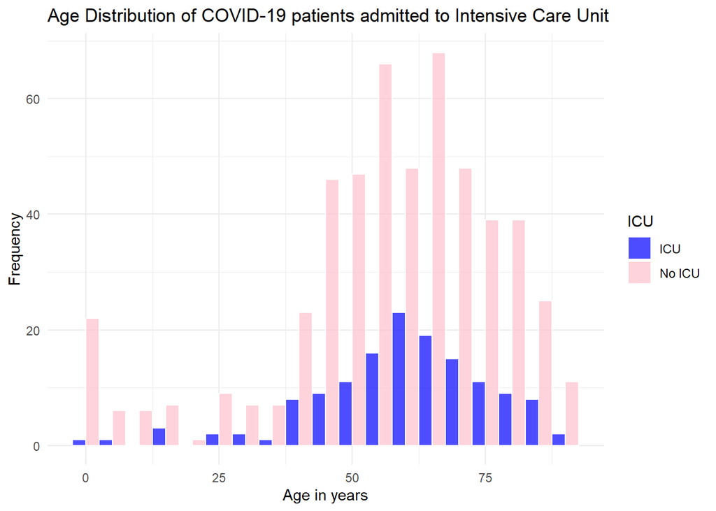